# Natural Language Processing - A Primer

## Sentiment analysis from “Text Mining with R: A Tidy Approach”

In this article we will explore natural language processing, specifically sentiment analysis, in R. We will start with the excellent examples provided in [“Text Mining with R: A Tidy Approach”](https://www.tidytextmining.com/) which introduce the clever use of joins to categorize tokens.

We’ll then apply what we’ve learned to a more topical dataset to exemplify some of the pitfalls of sentiment analysis.

```r
library(tidyverse)
library(tidytext)
library(textdata)
library(knitr)
```

Using the `tidyverse` and `tidytext` packages, sentiment analysis is very straightforward in R. The basic steps are as follows;

1. Load your corpus of documents and semantic library (`NRC` in this case)
2. Tokenize each document, in this case, into monograms (single words)
3. Left join your corpus dataset with the semantic data set on the tokens

The example below demonstrates how to do this manipulation, as well as some useful summary transformations at the end.

```r
library(janeaustenr)
library(dplyr)
library(stringr)

# Load corpus and generate tokens with some formatting
tidy_books <- austen_books() %>%
  group_by(book) %>%
  mutate(
    linenumber = row_number(),
    chapter = cumsum(str_detect(text,
                                regex("^chapter [\\divxlc]",
                                      ignore_case = TRUE)))) %>%
  ungroup() %>%
  unnest_tokens(word, text)
```

```r
# Load sentiment dataset
nrc_joy <- get_sentiments("nrc") %>%
  filter(sentiment == "joy")

# Join and display
tidy_books %>%
  filter(book == "Emma") %>%
  inner_join(nrc_joy) %>%
  count(word, sort = TRUE) |>
  head(10) |>
  kable()
```

| word | n |
| --- | --- |
| good | 359 |
| friend | 166 |
| hope | 143 |
| happy | 125 |
| love | 117 |
| deal | 92 |
| found | 92 |
| present | 89 |
| kind | 82 |
| happiness | 76 |

Our data now shows the count of each token associated with “joy” according the the `NRC` from Jane Austen’s book “Emma”.

## Mr. Donald Trump’s vs President Trump’s Tweets

We’ll now use a different lexical sentiment set from [M. Hu and B. Liu](https://www.cs.uic.edu/~liub/publications/kdd04-revSummary.pdf) called `huliu` to analyze another set of corpora; Donald Trump’s tweets both before and during his presidency. Credit to [MarkHershey](https://github.com/MarkHershey/CompleteTrumpTweetsArchive) for collecting both datasets.

We need to do a bit of adjusting of the `huliu` dataset to make it fit our analysis.

```r
library(lexicon)

# Load the huliu sentiment set
huliu <- tibble(hash_sentiment_huliu)

# Need to update stop words to suppress outliers & noise
custom_stop_words <- c("overly", "great", "trump")

# Format the sentiment from integers to postive / negative
huliu <- huliu |>
  rename("word" = "x", "sentiment" = "y") |>
  filter(!word %in% custom_stop_words) |>
  mutate(sentiment = as.character(sentiment)) |>
  mutate(sentiment = case_when(
    sentiment == "1" ~ "positive",
    sentiment == "-1" ~ "negative"
  ))
```

We will start with Donald Trump’s Tweets prior to his presidency.

### Before Presidency

We’ll load the pre-presidency tweets and perform the same steps as demonstrated before to tokenize our corpus and then join with the semantic data.

```r
dttbf <- read_csv('realDonaldTrump_bf_office.csv')
```

```r
# Tokenize the documents
dttbf_tokens <- dttbf |>
  mutate(tweet_number = row_number()) |>
  unnest_tokens(word, "Tweet Text")
```

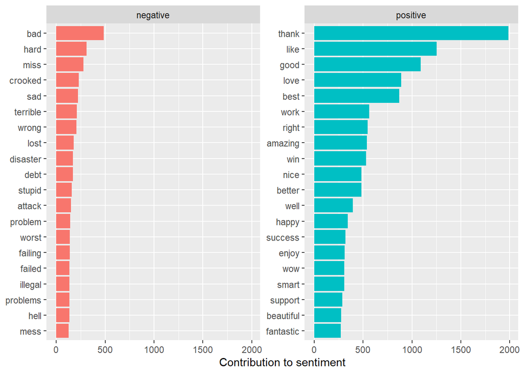

```r
# Join with the sentiment set
dttbf_sentiments <- dttbf_tokens |>
  inner_join(huliu) |>
  count(word, sentiment, sort = TRUE) |>
  ungroup() |>
  group_by(sentiment) |>
  slice_max(n, n = 20) |>
  ungroup() |>
  mutate(word = reorder(word, n))

# Plot the top words contributing to sentiment
  ggplot(dttbf_sentiments, aes(n, word, fill = sentiment)) +
  geom_col(show.legend = FALSE) +
  facet_wrap(~sentiment, scales = "free_y") +
  labs(x = "Contribution to sentiment",
       y = NULL)
```

You probably have some initial reaction to this data, but this is the pitfall we aluded to in the introduction. **We must be cautious when evaluating language data as we’re missing context when we tokenize into monograms**.

For example, we can see that `hard` is a large contributor to the negative sentiment, however the word can certainly be used in the context of “hard work”, which would generally be viewed as positive.

On the positive side (pun intended), we see words like `thank` and `like` have a massive impact, which again are highly dependent on context. A word like `thank` could easily be part of an exasperated “thank god” or “no thank you”, and `like` is used to compare things; not necessarily a positive word by itself.

Note that we’ve also intentionally excluded words like “great” and “trump” for obvious reasons.

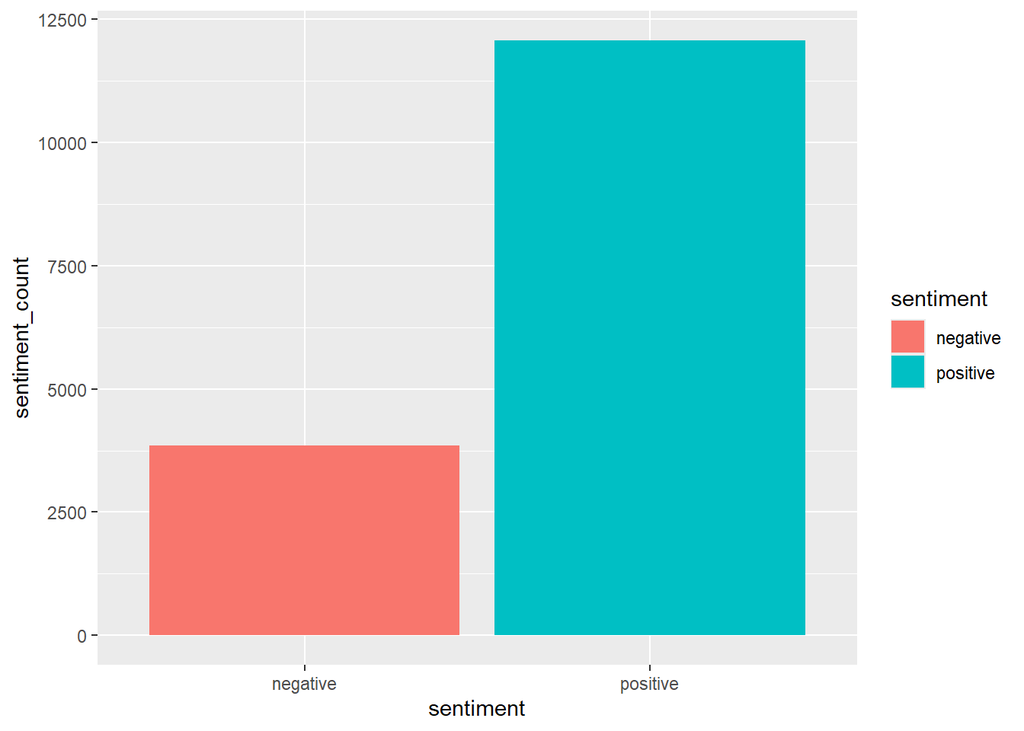

```r
# Group sentiments into positive and negative counts
dttbf_sentiments |>
  group_by(sentiment, n) |>
  summarize(sentiment_count = sum(n)) |>
  ungroup() |>

# Plot
ggplot(aes(sentiment, sentiment_count, fill = sentiment)) +
  geom_col()
```

### During presidency

Now we’ll repeat the process for the tweets while Mr. Trump was president.

```r
# Load tweets
dtt <- read_csv('realDonaldTrump_in_office.csv')
```

```r
dtt_tokens <- dtt |>
  mutate(tweet_number = row_number()) |>
  unnest_tokens(word, "Tweet Text")
```

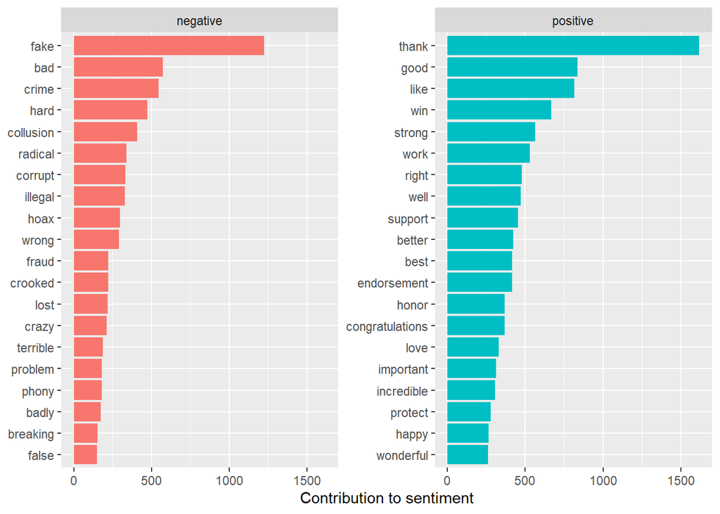

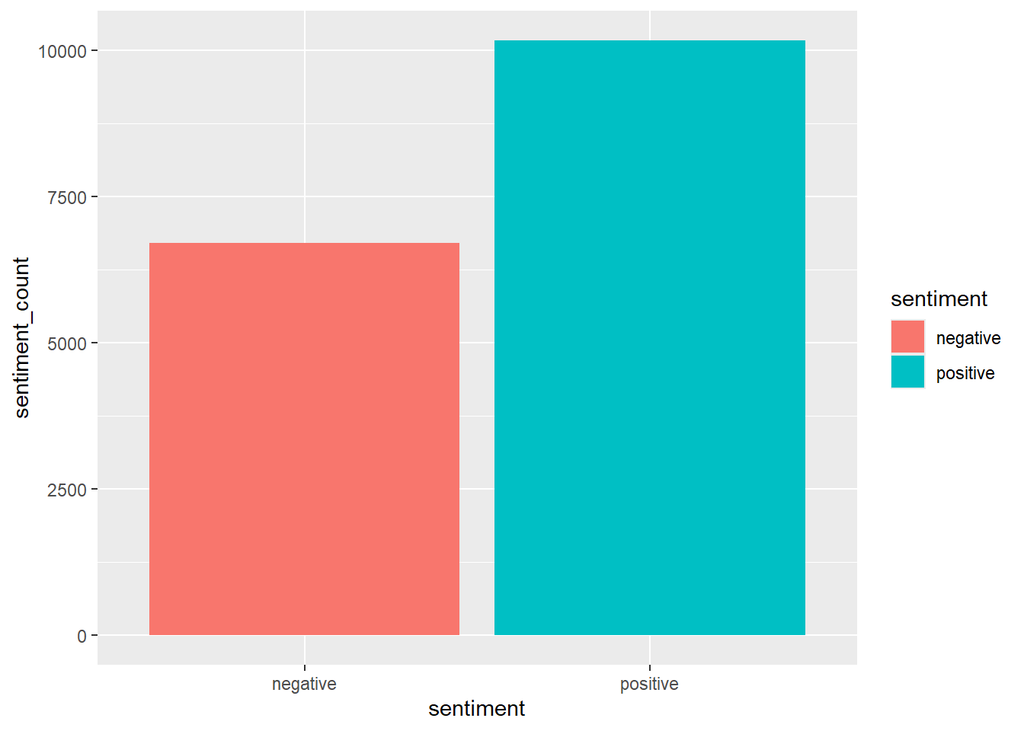

## Conclusion

Sentiment analysis, along with most natural language process, is perhaps the most “artful” modeling a data scienctist can perform, given the complexity and nuance of language. As we’ve seen in this data, it is easy to naively assume sentiment with a particular word, only to realize in context it’s perhaps used more often with a particular idiom with a completely opposite sentiment!

As data scientists, we must always remember to interpret our data in our domain context, especially in natural language processing.